# Augmenting designs with controlled efficiency loss

```r
library(optedr)
```

## Motivation

In practice an experiment is rarely designed from scratch. A researcher may already have data collected at certain conditions and want to add new observations to improve estimation — without discarding what has already been measured. The key question is: *where* can new points be placed so that the efficiency of the augmented design stays above an acceptable threshold?

**optedr** answers this question with two functions used in sequence:

1. `get_augment_region()` — computes the candidate region: the set of design points whose addition keeps the D-efficiency of the augmented design above a user-specified threshold `delta_val`.
2. `augment_design()` — adds a chosen point to the initial design and rescales the weights.

Both functions support the same optimality criteria as `opt_des()` and work for any number of factors.

## Key parameters

| Parameter | Role |
| --- | --- |
| `init_design` | Current design (data frame with `Point`/`Weight` in 1D, or factor columns + `Weight` in multi-D) |
| `alpha` | Fraction of total weight assigned to the new point after augmentation |
| `delta_val` | Minimum acceptable D-efficiency of the augmented design |
| `calc_optimal_design` | If `TRUE`, also computes the optimal design and uses it as the reference for efficiency |
| `new_points` | Data frame of points to add (non-interactive mode); omit for interactive mode |
| `par_int` | Indices of parameters of interest (Ds-Optimality only) |
| `n_lhs` | Number of Latin-Hypercube candidates for the region search (multi-D) |

## One-factor augmentation

### Step 1: compute the candidate region

We start with a uniform three-point design for Antoine’s equation and look for points that keep the D-efficiency of the augmented design above 85 %.

```r
init_des <- data.frame(
  Point  = c(30, 60, 90),
  Weight = c(1/3, 1/3, 1/3)
)

region <- get_augment_region(
  criterion           = "D-Optimality",
  init_design         = init_des,
  alpha               = 0.25,
  model               = y ~ 10^(a - b / (c + x)),
  parameters          = c("a", "b", "c"),
  par_values          = c(8.07131, 1730.63, 233.426),
  design_space        = c(1, 100),
  calc_optimal_design = FALSE,
  delta_val           = 0.85
)
```

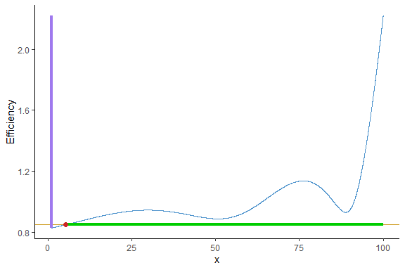

```r
print(region)
```

```
#> Augment candidate region  (delta = 0.8500)
#>   Intervals: [5.361, 100]
```

`region$region` is a data frame of candidate intervals. Each row gives a lower and upper bound on the design space where the new point can be placed.

### Step 2: choose a point and augment

```r
new_pt <- mean(region$region[1:2])

augmented <- augment_design(
  criterion           = "D-Optimality",
  init_design         = init_des,
  alpha               = 0.25,
  model               = y ~ 10^(a - b / (c + x)),
  parameters          = c("a", "b", "c"),
  par_values          = c(8.07131, 1730.63, 233.426),
  design_space        = c(1, 100),
  calc_optimal_design = FALSE,
  delta_val           = 0.85,
  new_points          = data.frame(Point = new_pt, Weight = 1)
)
```

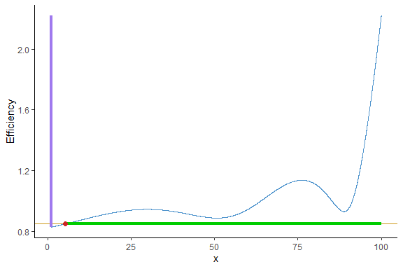

```r
print(augmented)
```

```
#>      Point Weight
#> 1 30.00000   0.25
#> 2 60.00000   0.25
#> 3 90.00000   0.25
#> 4 52.68026   0.25
```

```r
cat("Sum of weights:", sum(augmented$Weight), "\n")
```

```
#> Sum of weights: 1
```

### Comparing efficiency before and after

```r
result_opt <- opt_des(
  "D-Optimality",
  y ~ 10^(a - b / (c + x)), c("a", "b", "c"),
  c(8.07131, 1730.63, 233.426), c(1, 100)
)
```

```
#>
#> ℹ Stop condition not reached, max iterations performed
#> ⠙ Calculating optimal design 22 done (16/s) | 1.4sℹ The lower bound for efficiency is 99.9986187558838%
#>
```

```r
eff_before <- design_efficiency(init_des, result_opt)
```

```
#> ℹ The efficiency of the design is 38.5312233962882%
```

```r
eff_after  <- design_efficiency(augmented, result_opt)
```

```
#> ℹ The efficiency of the design is 34.2933573610529%
```

```r
cat("Efficiency before augmenting:", round(eff_before * 100, 2), "%\n")
```

```
#> Efficiency before augmenting: 38.53 %
```

```r
cat("Efficiency after augmenting: ", round(eff_after  * 100, 2), "%\n")
```

```
#> Efficiency after augmenting:  34.29 %
```

```r
cat("Gain:                        ", round((eff_after - eff_before) * 100, 2),
    "percentage points\n")
```

```
#> Gain:                         -4.24 percentage points
```

### Using the optimal design as reference (`calc_optimal_design = TRUE`)

When `calc_optimal_design = TRUE`, the function internally computes the optimal design and uses it to define the efficiency threshold. This is the recommended mode when no optimal design has been computed yet:

```r
region_opt <- get_augment_region(
  criterion           = "D-Optimality",
  init_design         = init_des,
  alpha               = 0.25,
  model               = y ~ 10^(a - b / (c + x)),
  parameters          = c("a", "b", "c"),
  par_values          = c(8.07131, 1730.63, 233.426),
  design_space        = c(1, 100),
  calc_optimal_design = TRUE,
  delta_val           = 0.85
)
```

## Two-factor augmentation

In multi-dimensional spaces `get_augment_region()` samples candidate points with a Latin Hypercube (controlled by `n_lhs`) and returns a data frame of candidates together with their estimated efficiency gain. A heatmap of the efficiency function is displayed automatically.

### Initial design and candidate region

```r
init_2d <- data.frame(
  x1     = c(0.8, 10, 5),
  x2     = c(10, 0.8, 5),
  Weight = c(1/3, 1/3, 1/3)
)

result_2D <- opt_des(
  criterion    = "D-Optimality",
  model        = y ~ Vmax * x1 * x2 / ((K1 + x1) * (K2 + x2)),
  parameters   = c("Vmax", "K1", "K2"),
  par_values   = c(1, 1, 1),
  design_space = list(x1 = c(0.1, 10), x2 = c(0.1, 10))
)
```

```
#>
#> ℹ Stop condition reached: difference between sensitivity and criterion < 1e-05
#> ⠙ Calculating optimal design 20 done (11/s) | 1.8sℹ The lower bound for efficiency is 99.9990066738592%
#>
```

```r
region_2d <- get_augment_region(
  criterion           = "D-Optimality",
  init_design         = init_2d,
  alpha               = 0.25,
  model               = y ~ Vmax * x1 * x2 / ((K1 + x1) * (K2 + x2)),
  parameters          = c("Vmax", "K1", "K2"),
  par_values          = c(1, 1, 1),
  design_space        = list(x1 = c(0.1, 10), x2 = c(0.1, 10)),
  calc_optimal_design = FALSE,
  delta_val           = 0.85
)
```

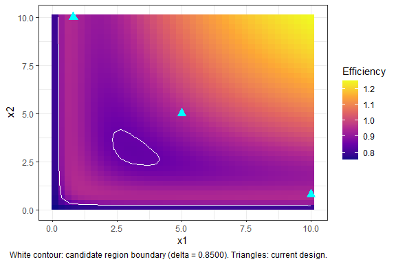

```
#> ℹ 1920 candidate points with efficiency >= 0.85 (from LHS sample of 2000)
```

`region_2d$region` is a data frame of sampled candidates, each with an `efficiency` column. Pick the candidate that maximises efficiency:

```r
best_2d <- region_2d$region[which.max(region_2d$region$efficiency), ]

eff_antes <- suppressMessages(design_efficiency(init_2d, result_2D))

aug_2d <- augment_design(
  criterion           = "D-Optimality",
  init_design         = init_2d,
  alpha               = 0.25,
  model               = y ~ Vmax * x1 * x2 / ((K1 + x1) * (K2 + x2)),
  parameters          = c("Vmax", "K1", "K2"),
  par_values          = c(1, 1, 1),
  design_space        = list(x1 = c(0.1, 10), x2 = c(0.1, 10)),
  calc_optimal_design = FALSE,
  delta_val           = 0.85,
  new_points          = data.frame(x1 = best_2d$x1, x2 = best_2d$x2, Weight = 1)
)
```

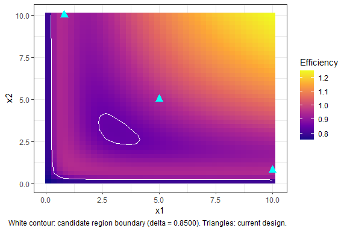

```
#> ℹ 1910 candidate points with efficiency >= 0.85 (from LHS sample of 2000)
#> Sample of candidate points:
#>          x1       x2 efficiency
#> 1  8.794390 0.212954  0.8582158
#> 2  6.838483 9.551944  1.1518121
#> 3  9.459755 1.825559  0.9033251
#> 4  9.972765 6.345771  1.1414484
#> 5  5.583301 8.467391  1.0770282
#> 6  0.523416 6.496930  0.9385391
#> 7  3.039475 0.515030  0.9331933
#> 8  4.600099 8.381351  1.0267086
#> 9  9.709010 5.238821  1.0868141
#> 10 7.185740 7.984717  1.1262232
#> 11 1.269713 5.595604  0.9042071
#> 12 9.849443 2.206128  0.9145444
#> 13 2.698294 7.970581  0.9129588
#> 14 1.789031 3.713830  0.8694875
#> 15 7.478578 8.792885  1.1563916

eff_despues <- suppressMessages(design_efficiency(aug_2d, result_2D))

cat("Efficiency before:", round(eff_antes  * 100, 2), "%\n")
#> Efficiency before: 68.4 %
cat("Efficiency after: ", round(eff_despues * 100, 2), "%\n")
#> Efficiency after:  85.12 %
print(aug_2d)
#>          x1        x2 Weight
#> 1  0.800000 10.000000   0.25
#> 2 10.000000  0.800000   0.25
#> 3  5.000000  5.000000   0.25
#> 4  9.834484  9.991616   0.25
```

## Three-factor augmentation

For three or more factors the candidate region is displayed as a scatter-matrix coloured by candidate/non-candidate status, with the current design shown as triangles.

```r
init_3d <- data.frame(
  x1     = c(0.8, 10,  10,  0.8, 10),
  x2     = c(10,  0.8, 10,  10,  0.8),
  x3     = c(10,  10,  0.8, 0.8, 10),
  Weight = rep(0.2, 5)
)

region_3d <- get_augment_region(
  criterion           = "D-Optimality",
  init_design         = init_3d,
  alpha               = 0.45,
  model               = y ~ Vmax * x1 * x2 * x3 / ((K1+x1) * (K2+x2) * (K3+x3)),
  parameters          = c("Vmax", "K1", "K2", "K3"),
  par_values          = c(1, 1, 1, 1),
  design_space        = list(x1 = c(0.1, 10), x2 = c(0.1, 10), x3 = c(0.1, 10)),
  calc_optimal_design = FALSE,
  delta_val           = 0.93
)
```

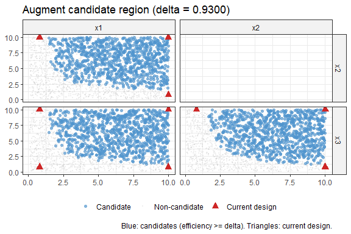

```
#> ℹ 981 candidate points with efficiency >= 0.93 (from LHS sample of 2000)
cat("Number of candidate points:", nrow(region_3d$region), "\n")
#> Number of candidate points: 981
plot(region_3d$plot)
```

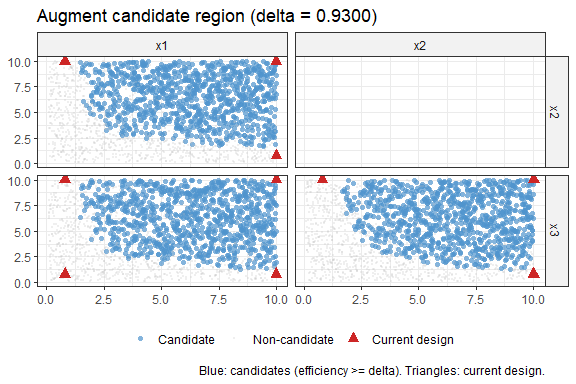

## Augmenting with Ds-Optimality

When the goal is to augment while preserving estimation quality for a *subset* of parameters, use `criterion = "Ds-Optimality"` and pass `par_int`:

```r
region_ds <- get_augment_region(
  criterion           = "Ds-Optimality",
  init_design         = init_2d,
  alpha               = 0.25,
  model               = y ~ Vmax * x1 * x2 / ((K1 + x1) * (K2 + x2)),
  parameters          = c("Vmax", "K1", "K2"),
  par_values          = c(1, 1, 1),
  design_space        = list(x1 = c(0.1, 10), x2 = c(0.1, 10)),
  calc_optimal_design = FALSE,
  par_int             = c(1),
  delta_val           = 0.85,
  n_lhs               = 5000
)
```

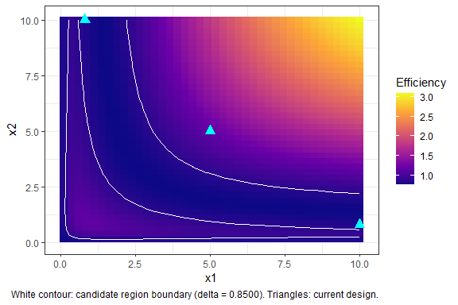

```
#> ℹ 3453 candidate points with efficiency >= 0.85 (from LHS sample of 5000)

best_ds <- region_ds$region[which.max(region_ds$region$efficiency), ]

aug_ds <- augment_design(
  criterion           = "Ds-Optimality",
  init_design         = init_2d,
  alpha               = 0.25,
  model               = y ~ Vmax * x1 * x2 / ((K1 + x1) * (K2 + x2)),
  parameters          = c("Vmax", "K1", "K2"),
  par_values          = c(1, 1, 1),
  design_space        = list(x1 = c(0.1, 10), x2 = c(0.1, 10)),
  calc_optimal_design = FALSE,
  par_int             = c(1),
  delta_val           = 0.85,
  new_points          = data.frame(x1 = best_ds$x1, x2 = best_ds$x2, Weight = 1),
  n_lhs               = 5000
)
```

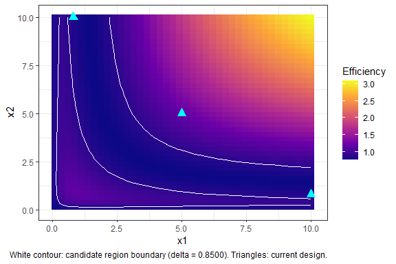

```
#> ℹ 3469 candidate points with efficiency >= 0.85 (from LHS sample of 5000)
#> Sample of candidate points:
#>           x1        x2 efficiency
#> 1  7.6032146 9.3698539  2.4871401
#> 2  6.3288098 2.7861100  0.8715261
#> 3  0.2309604 3.7634435  0.9144785
#> 4  9.0195639 9.0019514  2.7257777
#> 5  5.7033820 7.2771142  1.6913988
#> 6  6.6428368 4.2905667  1.2472598
#> 7  3.0184121 6.7119601  0.9384701
#> 8  5.1552525 8.1395227  1.6583790
#> 9  6.4106194 4.5610415  1.2870381
#> 10 5.5796609 0.7116589  0.8822207
#> 11 4.2507370 6.9246339  1.2670307
#> 12 4.6568340 5.0945095  1.1257668
#> 13 5.2756721 4.4240340  1.1090500
#> 14 6.9540511 6.5696378  1.8360266
#> 15 5.2299034 3.9739387  1.0192873
print(aug_ds)
#>          x1        x2 Weight
#> 1  0.800000 10.000000   0.25
#> 2 10.000000  0.800000   0.25
#> 3  5.000000  5.000000   0.25
#> 4  9.889364  9.929961   0.25
```

## Interactive mode

Omitting `new_points` (and `delta_val`) from both functions triggers an interactive session where the package plots the candidate region and asks the user to type a point. This mode is documented in `?augment_design`.